# Introduction to Programming using R

# Organizational Matters

*Lecturers:*

- Tim Mensinger (tim.mensinger@uni-bonn.de)

*Timetable:*

- Monday - Thursday, 9am - 4pm; Friday, 9am - 2pm
- Morning: Lectures and presenation of solutions
- Lunchbreak: 12-1pm
- Afternoon: Supervised learning

# Preliminaries

Before starting the class make sure to install the required software. We will be using the programming language R (R Core Team 2019) and the development environment RStudio (RStudio Team 2015). We recommend first installing R and then RStudio (desktop).

R Core Team. 2019. *R: A Language and Environment for Statistical Computing*. Vienna, Austria: R Foundation for Statistical Computing. https://www.R-project.org/.

RStudio Team. 2015. *RStudio: Integrated Development Environment for r*. Boston, MA: RStudio, Inc. http://www.rstudio.com/.

- R: https://cran.rstudio.com
- RStudio: https://rstudio.com/products/rstudio/download

# Introduction

“[…] computers and mathematics are like beer and potato chips: two fine tastes that are best enjoyed together. Mathematics provides the foundations of our models and of the algorithms we use to solve them. Computers are the engines that run these algorithms.” – (Stachurski 2009)

Stachurski, John. 2009. *Economic Dynamics: Theory and Computation*. Vol. 1. MIT Press Books 0262012774. The MIT Press. https://ideas.repec.org/b/mtp/titles/0262012774.html.

In this section we will present the very basics of R. We will go through some arithmetic, variables, special numerical objects, comments and data types.

All statements are typed into the R console and the results are displayed after `[1]`.

## Arithmetic

```r
1 + 1
```

```
[1] 2
```

```r
1 - 1
```

```
[1] 0
```

Decimals:

Note that the decimal mark is denoted by a dot (.) and not a comma (,).

```r
2.5 * 4
```

```
[1] 10
```

```r
1 / 3
```

```
[1] 0.3333333
```

```r
2 ^ 2 ^ 3
```

```
[1] 256
```

```r
2 ** 2 ** 3
```

```
[1] 256
```

Parentheses:

If in doubt use parentheses to ensure that R will compute the correct expression.

```r
(2 ** 2) ** 3
```

```
[1] 64
```

## Variables

```r
x <- 10 + 5
x
```

```
[1] 15
```

```r
x <- x + x
x
```

```
[1] 30
```

```r
x ** 2
```

```
[1] 900
```

```r
y <- x
y
```

```
[1] 30
```

## Special Numerical Objects

Constants, infinity and NaNs (Not a Number):

```r
pi
```

```
[1] 3.141593
```

```r
1/0
```

```
[1] Inf
```

```r
0/0
```

```
[1] NaN
```

## Data Types

- `numeric`: `x <- 1.25`
- `integer`: `x <- 1L`
- `character`: `x <- "this_works"`

  This data type is also known as a String.
- `logical`: `x <- TRUE`, `y <- FALSE`
- `complex`: `x <- 1 + 2i`

# Data Structures

In this section we consider the most common data structures used in R. This includes

- `list`
- `(atomic) vector`
- `matrix`
- `data.frame`

## Lists

Lists are objects which can contain different objects of different data types.

`list` is a (built-in) function which takes as argument multiple objects and combines them to a list. See section function.`print` is a (built-in) function which prints its argument on the console.

`length` is a (built-in) function which returns the length of its argument.

```r
x <- list(1, 1.25, "this works?")
x
```

```
[[1]]
[1] 1

[[2]]
[1] 1.25

[[3]]
[1] "this works?"
```

```r
x <- list(x, 1 + 2i)
x
```

```
[[1]]
[[1]][[1]]
[1] 1

[[1]][[2]]
[1] 1.25

[[1]][[3]]
[1] "this works?"


[[2]]
[1] 1+2i
```

```r
length(x)
```

```
[1] 2
```

## Vectors

Vectors are similar to lists in that they can contain multiple objects, however, any vector can contain only objects of one data type.

`c` is a (built-in) function which takes as argument multiple objects of the same data type and combines them to a vector. `c` stands for `combine`.

```r
x <- c(1, 2, 3)
x
```

```
[1] 1 2 3
```

```r
x <- c("this", "actually", "works")
x
```

```
[1] "this"     "actually" "works"
```

```r
x <- c("wait?", 1)
x
```

```
[1] "wait?" "1"
```

```r
length(x)
```

```
[1] 2
```

## Indexing of Lists and Vectors

We access elements of lists and vectors via their index. If `x` is a list (or vector) we get the `i`-th element as `x[i]`. Note that for a list (or vector) of length `n` we can of course only ask for elements `1` to `n`, otherwise R returns `NA` which stands for Not Available. If we supply a vector of indices we can access more than one element, i.e. `x[c(1, 3, 5)]` will return the first, third and fifth element of `x`.

This is slightly different to many other programming languages which start indexing at `0` instead of `1`.

Examples:

Note the difference between `y[1]` and `y[[1]]` for lists.

```r
x <- c(2, 4, 6, 8, 10)
x[1]
```

```
[1] 2
```

```r
x[2]
```

```
[1] 4
```

```r
x[6]
```

```
[1] NA
```

```r
x[6] <- 0
x
```

```
[1]  2  4  6  8 10  0
```

```r
x[c(1, 3, 5)]
```

```
[1]  2  6 10
```

```r
x[3] <- 100
x
```

```
[1]   2   4 100   8  10   0
```

```r
x[c(2, 4)] <- -100
x
```

```
[1]    2 -100  100 -100   10    0
```

```r
x[-1]
```

```
[1] -100  100 -100   10    0
```

```r
x[-c(1, 2)]
```

```
[1]  100 -100   10    0
```

```r
y <- list(1, 1.25, "this works?")
y[1]
```

```
[[1]]
[1] 1
```

```r
y[[1]]
```

```
[1] 1
```

Useful commands:

`seq` is a (built-in) function which produces sequences from a specified number to another; with the extra argument `by` one can specify the increment; with the extra argument `length.out` one can specify the desired length of the sequence.

A quick way to create sequences which increment by one is by using the syntax `a:b` to create the sequence (vector) `c(a, a + 1, ..., b - 1, b)`.

```r
x <- 1:10
x
```

```
 [1]  1  2  3  4  5  6  7  8  9 10
```

```r
x <- seq(from=1, to=10, by=2)
x
```

```
[1] 1 3 5 7 9
```

```r
x <- seq(from=0, to=1, length.out=20)
x
```

```
 [1] 0.00000000 0.05263158 0.10526316 0.15789474 0.21052632 0.26315789 0.31578947 0.36842105
 [9] 0.42105263 0.47368421 0.52631579 0.57894737 0.63157895 0.68421053 0.73684211 0.78947368
[17] 0.84210526 0.89473684 0.94736842 1.00000000
```

## Calculating with Vectors

```r
x <- 1:10
x
```

```
 [1]  1  2  3  4  5  6  7  8  9 10
```

```r
y <- -4:5
y
```

```
 [1] -4 -3 -2 -1  0  1  2  3  4  5
```

```r
x + y
```

```
 [1] -3 -1  1  3  5  7  9 11 13 15
```

```r
x * y
```

```
 [1] -4 -6 -6 -4  0  6 14 24 36 50
```

```r
x ** y
```

```
 [1] 1.000000e+00 1.250000e-01 1.111111e-01 2.500000e-01 1.000000e+00 6.000000e+00 4.900000e+01
 [8] 5.120000e+02 6.561000e+03 1.000000e+05
```

```r
2 * x
```

```
 [1]  2  4  6  8 10 12 14 16 18 20
```

```r
10 + x
```

```
 [1] 11 12 13 14 15 16 17 18 19 20
```

```r
x ** 2
```

```
 [1]   1   4   9  16  25  36  49  64  81 100
```

Recycling:

```r
x <- 1:4
y <- c(1, 5, 10)
x + y
```

```
[1]  2  7 13  5
```

(Some) useful functions:

`sum` is a (built-in) function which sums all elements of its argument (also works on matrices). `mean` computes the mean of its argument, `sd` the (unbiased) standard deviation, `var` the variance and `cumsum` the cumulative sum.

```r
x <- -5:5
x
```

```
 [1] -5 -4 -3 -2 -1  0  1  2  3  4  5
```

```r
sum(x)
```

```
[1] 0
```

```r
mean(x)
```

```
[1] 0
```

```r
sd(x)
```

```
[1] 3.316625
```

```r
var(x)
```

```
[1] 11
```

```r
cumsum(x)
```

```
 [1]  -5  -9 -12 -14 -15 -15 -14 -12  -9  -5   0
```

## Matrices

Matrices represent two dimensional arrays which works similar to vectors in that matrices can only contain objects of a single data type. To create a matrix we need to know how many rows and columns it should have and what data it should contain.

Note that `1:x` is equivalent to `c(1,2,...,x)`. Also note `matrix(data, rows, cols)` is not equal to `matrix(data, cols, rows)`; if you do not know which argument comes when, simply ask R for help: `?matrix`. (This works for any `R` function, just type `?function_name`).

```r
data <- 1:9
rows <- 3
cols <- 3

x <- matrix(data, rows, cols)
x
```

```
     [,1] [,2] [,3]
[1,]    1    4    7
[2,]    2    5    8
[3,]    3    6    9
```

```r
y <- matrix(data, rows, cols, byrow=TRUE)
y
```

```
     [,1] [,2] [,3]
[1,]    1    2    3
[2,]    4    5    6
[3,]    7    8    9
```

```r
dim(x)
```

```
[1] 3 3
```

```r
nrow(x)
```

```
[1] 3
```

```r
ncol(x)
```

```
[1] 3
```

## Combining Vectors and Matrices

When computing different intermediate results it is often useful to combine them to get an end result.

The (built-in) function `rbind` takes two matrices (or data frames) as input and stacks them on top of each other (on the rows). Similarly, `cbind`, stacks the two arrays next to each other (on the columns).

```r
x <- matrix(1:9, 3)
x
```

```
     [,1] [,2] [,3]
[1,]    1    4    7
[2,]    2    5    8
[3,]    3    6    9
```

```r
y <- matrix(1:6, 2)
y
```

```
     [,1] [,2] [,3]
[1,]    1    3    5
[2,]    2    4    6
```

```r
z <- rbind(x, y)
z
```

```
     [,1] [,2] [,3]
[1,]    1    4    7
[2,]    2    5    8
[3,]    3    6    9
[4,]    1    3    5
[5,]    2    4    6
```

```r
x <- cbind(1:3, 4:6)
x
```

```
     [,1] [,2]
[1,]    1    4
[2,]    2    5
[3,]    3    6
```

(Some) useful functions:

`rowSums` computes the sum of each row of a matrix (or data frame) and returns the resulting vector. `colSums` , `rowMean` and `colMeans` work analogously.

```r
m <- matrix(1:9, 3)
m
```

```
     [,1] [,2] [,3]
[1,]    1    4    7
[2,]    2    5    8
[3,]    3    6    9
```

```r
rowSums(m)
```

```
[1] 12 15 18
```

```r
colSums(m)
```

```
[1]  6 15 24
```

```r
rowMeans(m)
```

```
[1] 4 5 6
```

In more general settings we might wish to apply an arbitrary function to the rows or columns of a matrix. We can do this with the function `apply`. Example:

`apply(X, MARGIN, FUN)`, `X` = matrix of interest, `MARGIN` = 1 to apply the function over the rows and 2 to apply the function over the columns, `FUN` = the function of interest.

```r
m <- matrix(1:9, 3)
apply(m, 1, sd)
```

```
[1] 3 3 3
```

```r
apply(m, 2, sd)
```

```
[1] 1 1 1
```

## Matrix algebra

Note the difference between `X * y` and `X %*% y`; the first multiples the `i`th element of `y` onto the `i`th row of `X` and the second computes the regular matrix product known from linear algebar.

```r
X <- matrix(1:9, 3)
y <- -1:1

X * y
```

```
     [,1] [,2] [,3]
[1,]   -1   -4   -7
[2,]    0    0    0
[3,]    3    6    9
```

```r
X %*% y
```

```
     [,1]
[1,]    6
[2,]    6
[3,]    6
```

```r
X * X
```

```
     [,1] [,2] [,3]
[1,]    1   16   49
[2,]    4   25   64
[3,]    9   36   81
```

```r
X %*% X
```

```
     [,1] [,2] [,3]
[1,]   30   66  102
[2,]   36   81  126
[3,]   42   96  150
```

(Some) useful functions:

`t` computes the transpose of its argument, which can be either a matrix or a data frame. `diag` returns the diagonal entries of its argument. `solve` can be used to either solve a linear system of equations or compute the inverse of its argument: if we provide `solve` with one matrix (or data frame) then it returns the inverse; if we supply a matrix (or data frame) and a vector, `solve` returns the solution to the system of linear equations. That is, $\text{solve}(X) = X^{-1}$ and $\text{solve}(X, y) = b$ with $X b = y$ (if the system has a solution).

```r
t(X)
```

```
     [,1] [,2] [,3]
[1,]    1    2    3
[2,]    4    5    6
[3,]    7    8    9
```

```r
diag(X)
```

```
[1] 1 5 9
```

```r
A <- matrix(c(1, 10, -2, 3), 2)
A
```

```
     [,1] [,2]
[1,]    1   -2
[2,]   10    3
```

```r
solve(A)
```

```
           [,1]       [,2]
[1,]  0.1304348 0.08695652
[2,] -0.4347826 0.04347826
```

```r
b <- c(-1, 1)
solve(A, b)
```

```
[1] -0.04347826  0.47826087
```

## Data Frames

Data frames represent data sets. The difference to matrices is that different columns can have different data types. Note that there are many different ways of creating a data frame.

```r
x <- c("Micheal", "Robin", "Jonah")
y <- c(1.0, 1.3, 3.0)
z <- c("a", "b", "c")

df <- data.frame(name=x, grades=y, type=z)
df
```

```
     name grades type
1 Micheal    1.0    a
2   Robin    1.3    b
3   Jonah    3.0    c
```

```r
m <- matrix(1:9, 3)
df <- as.data.frame(m)
df
```

```
  V1 V2 V3
1  1  4  7
2  2  5  8
3  3  6  9
```

The iris data set:

The function `head` returns the first few rows of a data frame, which can be useful to have a quick glance at a data frame. `str` returns the internal structure of its argument and is particularly useful for data frames to output the key information in a data set.

```r
head(iris)
```

```
  Sepal.Length Sepal.Width Petal.Length Petal.Width Species
1          5.1         3.5          1.4         0.2  setosa
2          4.9         3.0          1.4         0.2  setosa
3          4.7         3.2          1.3         0.2  setosa
4          4.6         3.1          1.5         0.2  setosa
5          5.0         3.6          1.4         0.2  setosa
6          5.4         3.9          1.7         0.4  setosa
```

```r
str(iris)
```

```
'data.frame':   150 obs. of  5 variables:
 $ Sepal.Length: num  5.1 4.9 4.7 4.6 5 5.4 4.6 5 4.4 4.9 ...
 $ Sepal.Width : num  3.5 3 3.2 3.1 3.6 3.9 3.4 3.4 2.9 3.1 ...
 $ Petal.Length: num  1.4 1.4 1.3 1.5 1.4 1.7 1.4 1.5 1.4 1.5 ...
 $ Petal.Width : num  0.2 0.2 0.2 0.2 0.2 0.4 0.3 0.2 0.2 0.1 ...
 $ Species     : Factor w/ 3 levels "setosa","versicolor",..: 1 1 1 1 1 1 1 1 1 1 ...
```

## Indexing of Matrices and Data Frames

Matrices and data frames constitute two dimensional objects, this means we can ask for submatrices, columns, rows or individual elements.

```r
m <- matrix(1:9, 3)
m
```

```
     [,1] [,2] [,3]
[1,]    1    4    7
[2,]    2    5    8
[3,]    3    6    9
```

```r
m[1, 1]
```

```
[1] 1
```

```r
m[1, ]
```

```
[1] 1 4 7
```

```r
m[, 1]
```

```
[1] 1 2 3
```

```r
m[c(1, 2), c(2, 3)]
```

```
     [,1] [,2]
[1,]    4    7
[2,]    5    8
```

When dealing with data frames we can also access the columns by their respective names.

To access a column of a data frame by name use `df$column_name`. Note the different results of `df[["grade"]]` and `df["grade"]`.

```r
df <- data.frame(name=c("Thomas", "Susan"), grade=c(1, 2))
df
```

```
    name grade
1 Thomas     1
2  Susan     2
```

```r
df$name
```

```
[1] "Thomas" "Susan"
```

```r
df[["grade"]]
```

```
[1] 1 2
```

```r
df["grade"]
```

```
  grade
1     1
2     2
```

# Digression on asserting data types

When building programs which handle data and objects that are unknown while developing the code it is often necessary to check of what type they are. Say we get an object (a variable) `x` from somewhere and we need to evaluate if its a number or data frame; and if it is a number, is it an integer or a real number. For these questions are supplies the many functions of the type `is.vector`, `is.matrix`, `is.integer`. We will not list them all and only provide a small example.

```r
x <- 1:10
is.integer(x)
```

```
[1] TRUE
```

```r
is.numeric(x)
```

```
[1] TRUE
```

```r
is.vector(x)
```

```
[1] TRUE
```

```r
is.data.frame(x)
```

```
[1] FALSE
```

```r
is.function(x)
```

```
[1] FALSE
```

# Logical Operators

In this section we consider logical operators which form the direct equivalent to logical operators in mathematics. We first note that we can induce boolean values by comparison via relations (`<`, `>`, `<=`, `>=`) or (in)equalities (`==`, `!=`). On boolean values we may use logical operators as and (`&`), or (`|`), but also quantifier as $\exists$ (`any`) and $\forall$ (`all`).

```r
x <- 1:10

x < 5
```

```
 [1]  TRUE  TRUE  TRUE  TRUE FALSE FALSE FALSE FALSE FALSE FALSE
```

```r
sum(x < 5)
```

```
[1] 4
```

```r
x[x < 5]
```

```
[1] 1 2 3 4
```

```r
x[!(x < 5)]
```

```
[1]  5  6  7  8  9 10
```

```r
x[(x < 3) | (x > 7)]
```

```
[1]  1  2  8  9 10
```

```r
x[(x < 8) & (x > 3)]
```

```
[1] 4 5 6 7
```

```r
any(x < 8)
```

```
[1] TRUE
```

```r
all(x < 8)
```

```
[1] FALSE
```

Often we are interested in the (indices of the) elements of a vector (matrix) that fulfill a certain condition.

```r
x <- c(3, 2, -100, 400)
which(x > 100)
```

```
[1] 4
```

# Conditional Expressions

In many scenarios our decisions depend on the specific state of the situation. For example, *if* it rains we will take the umbrella with us. Or a little more complex. *If* it rains we will take the umbrella, otherwise, *if* we fixed the flat bike tires already we will go by bike. (We illustrate the a fictional conditional decision tree on the blackboard.) This brings us to conditional expressions.

## `if`

```r
x <- 10
if (x < 10) {
  print("x is smaller than 10.")
}
```

## `else`

```r
x <- 10
if (x < 10) {
  print("x is smaller than 10.")
} else{
  print("x is *not* smaller than 10.")
}
```

```
[1] "x is *not* smaller than 10."
```

## `else if`

```r
x <- 10
if (x < 10) {
  print("x is smaller than 10.")
} else if (x > 0) {
  print("x is between 0 and 10.")
} else {
  print("x is either smaller than 0 or bigger than 10.")
}
```

```
[1] "x is between 0 and 10."
```

## Short digression into `User Input`

Sometimes we want to write programs which work in many different scenarios that can be specified by the user of the program.

Note that the (built-in) function `readline` reads input from the user in the `R` console and stores it as a string.

The function `as.integer` takes as argument an `R` object and tries to coerce the input to an `integer` if possible; For example the string `"1"` can be coerced to a `1` but the string `"text"` cannot.

```r
cat("Please choose which type of regression should be run:\n")
x <- readline(prompt="Linear regression (1); Polynomial regression (2): ")
x <- as.integer(x)

if (x == 1) {
  print("Okay lets do linear regression!")
} else if (x == 2) {
  print("Oh no I hate polynomial regression :(")
} else {
  print("There were only two options what did you do?")
}
```

# Control Flow Statements

When working on nearly any project we often find ourselves repeating simple tasks over and over again. If this happens with tasks that cannot be managed on a computer we hire research assistants; however, if it can be done on a computer there are cheaper ways.

## For Loops

Let’s say we want to create a list with 10 entries and the `i`th entry is a matrix of dimension `i`x`i` filled with numbers 1 to $i^2$. This can be achieved very easily with a `for` loop.

```r
matrices <- list()
for (i in 1:10) {
  imatrix <- matrix(1:(i ** 2), nrow=i)

  matrices[[i]] <- imatrix
}
matrices[[5]]
```

```
     [,1] [,2] [,3] [,4] [,5]
[1,]    1    6   11   16   21
[2,]    2    7   12   17   22
[3,]    3    8   13   18   23
[4,]    4    9   14   19   24
[5,]    5   10   15   20   25
```

## Short digression into Monte Carlo simulation

Say we have two uniform random variables on $[0, 1]$, i.e. $X, Y \sim \mathcal{U}[0, 1]$. And say we want to estimate $\mathbb{P}(X + Y \in [0.75, 1.25])$ without doing any analytical mathematics. One solution to problems of this kind are so called Monte Carlo estimates, in which we simulate (in this case) two uniform random variables for many many times and each time we simply check if the sum of the realizations fulfills the statement. The frequency of times when the statement was fulfilled then approximates the probability.

In the latter chapters we will consider the function `runif` in more detail; for here only note that `runif(1, 0, 1)` evaluates to a realization of a uniform random variable on $[0, 1]$.

Note the use of `#` which tells `R` to ignore the following statement; These are called comments and should be used to clarify ones code.

```r
count <- 0
nsim <- 10000
for (i in 1:nsim) {
  x <- runif(1, min=0, max=1)
  y <- runif(1, min=0, max=1)

  z <- x + y
  if (z >= 0.75 && z <= 1.25) {
    count <- count + 1
  }

}
count / nsim # analytical solution = 7/6 = 0.4375
```

```
[1] 0.4356
```

## While Loops

For loops are very useful if we know exactly how many times we need to execute some statement. If we do not know the number of repetitions before starting the loop we can use `while` loops.

Example:

```r
userinput <- NULL
while(is.null(userinput)) {
  input <- readline("Type in a number between 0 and 10. \n")
  input <- as.integer(input)

  if (is.numeric(input)) {
    if (input >= 0 && input <= 10) {
      userinput <- input
    }
  }
}
userinput
```

# Functions

Functions are arguably the most important building block when writing large programs. We have already seen the use of many (built-in) functions. Functions, in general, allow us to use a piece of code multiple times in a program without repeating all of the code at every instance.

## A normal example

Say we need to compute the value of a normal density with mean `mu` and standard deviation `sigma` at some point `x`. In case we need to compute this value for many different means, variances or points we can save on time (and erros) by implementing a function once.

Note the use of special (built-in) mathematical functions `sqrt` and `exp`, which compute the square root and exponential of their arguments, respectively.

The (built-in) function `curve` displays the graph of a (mathematical) function.

```r
normaldensity <- function(x, mu, sigma) {
  constant <- 1 / sqrt(2 * pi * sigma ** 2)
  exponential <- exp(- (x - mu) ** 2 / (2 * sigma ** 2))

  return(constant * exponential)
}

normaldensity(x=0, mu=0, sigma=1)
```

```
[1] 0.3989423
```

```r
normaldensity(x=1, mu=0, sigma=1)
```

```
[1] 0.2419707
```

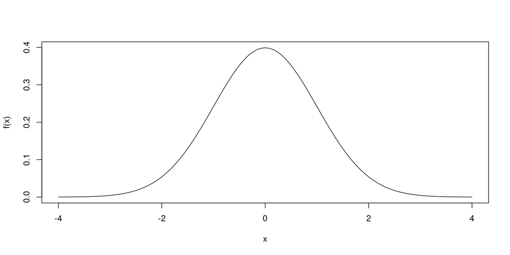

```r
standardnormaldensity <- function(x) {
  normaldensity(x, mu=0, sigma=1)
}

curve(standardnormaldensity, from=-4, to=4, xlab="x", ylab="f(x)")
```

## Recursive functions

The Fibonacci sequence is defined by the following (recursive) function
$$f(n) = \begin{cases}0, \, n =0\\ 1, \, n = 1\\ f(n-1) + f(n-2), \, n > 1 \,.\end{cases}$$
We can implement this function easily using an `R` function.

The (built-in) function `sapply` applies a function to each element of its first argument, which is typically a `list` or a `vector`.

```r
fibonacci <- function(n) {
  if (n == 0) {
    return(0)
  } else if (n == 1) {
    return(1)
  } else {
    return(fibonacci(n - 1) + fibonacci(n - 2))
  }
}

n <- 1:10
fib <- sapply(n, fibonacci)
rbind(n, fib)
```

```
    [,1] [,2] [,3] [,4] [,5] [,6] [,7] [,8] [,9] [,10]
n      1    2    3    4    5    6    7    8    9    10
fib    1    1    2    3    5    8   13   21   34    55
```

# Importing and Exporting Data

This section shows you how to import data from different file types into `R`. Before we start, some remarks are in order.

- Variables should be kept in columns, observations in rows
- Missing values should be coded consistently (e.g. `NA`)
- Variable names must not begin with a number and must not contain `#`, `%` or spaces
- Don’t ever replace the source file
- Check whether whether reading was successful before (!) starting your analysis

## Importing .txt, .csv, and .dta files

For many file types, importing is facilitated by base-`R` functions. For example, importing a .txt file can be achieved with

`read.table(file, header = FALSE, sep = "", dec = ".",...)`,

where `file` is the location of the file to be imported, `header` indicates whether the first line of the file contains variable names, `sep` is the field separator character, and `dec` is the character used in the file for decimal points. Similarly, if your data comes in .csv format you would go for

Note that standard backslashes (the Windows default) do not work and need to be replaced by either forwardslashes or double backslashes, i.e. `"../data/mtcars.txt"` or `"..\\data\\mtcars.txt"` instead of `"..\data\mtcars.txt"`)

`read.csv(file, header = TRUE, sep = ",", dec = ".",...)`.

`R` can also deal with the standard file types from `Stata`, `SPSS`, and `SAS`, among many others. Reading those might involve commands from additional `R`-packages.

`R` also has an own file type, `.RData`. These files can be read using

`load(file)`

As an example, let us look at the dataset that can be found in the GitHub repo of this course.

```r
dat <- read.table("mtcars.txt", header = TRUE, sep = "")
head(dat)
```

```
                   mpg cyl disp  hp drat    wt  qsec vs am gear carb
Mazda RX4         21.0   6  160 110 3.90 2.620 16.46  0  1    4    4
Mazda RX4 Wag     21.0   6  160 110 3.90 2.875 17.02  0  1    4    4
Datsun 710        22.8   4  108  93 3.85 2.320 18.61  1  1    4    1
Hornet 4 Drive    21.4   6  258 110 3.08 3.215 19.44  1  0    3    1
Hornet Sportabout 18.7   8  360 175 3.15 3.440 17.02  0  0    3    2
Valiant           18.1   6  225 105 2.76 3.460 20.22  1  0    3    1
```

In `R-Studio` you might want to use `View(dat)` to get an overview.

## Exporting

Similar to the `read`-commands, you can save objects using the `write`-commands. For instance, we might save a dataframe in our workspace as a .csv using

`write.csv(x, file = "",...)`,

where `x` is the object to be written and `file` is path where the object ought to be saved. If you would like to save the object as a `.RData` file, the syntax is

`save(...)`,

where `...` are the names of the objects to be saved.

To save the object in our workspace to a .csv, we execute the following command.

```r
write.csv(dat, file = "mtcars.csv")
```

# Plotting Data

Plots can be powerful tool to summarize data succinctly. This section provides a short overview of plotting capabilities of base `R`.

Advanced users usually create their plots using the `ggplot2` package developed by Hadley Wickham. If you are interested, have a look here: https://ggplot2.tidyverse.org/

Generally, base-`R` distinguishes between two types of graphics commands, high- and low-level commands. While a high-level command creates a plot (and overwrites a previously displayed plot), low-level commands are used to add things to an existing plot. High-level commands include, among others, `plot`, `hist`, `barplot`, `boxplot`, `qqnorm`, and `curve`.

As an example, consider the following data, where $Y$ is the crop yield of corn and $X$ is the amount of fertilizer used at each farm, respectively.

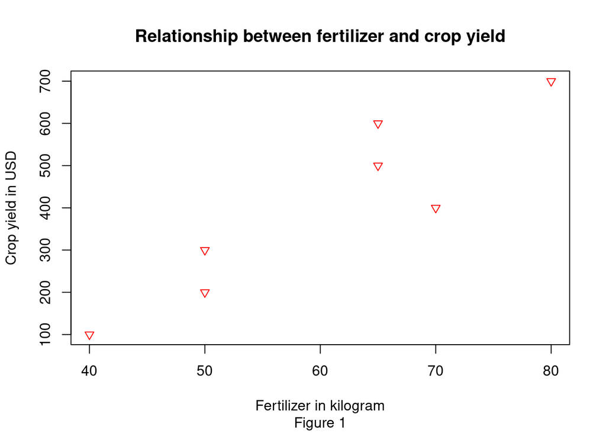

```r
Y <- c(100, 200, 300, 400, 500, 600, 700)
X <- c(40, 50, 50, 70, 65, 65, 80)
plot(X, Y, main = "Relationship between fertilizer and crop yield", sub = "Figure 1",
     xlab = "Fertilizer in kilogram", ylab = "Crop yield in USD",
     pch = 25, col = "red")
```

As is vividly illustrated in the previous example, the `plot`-command has various optional features. Let us try some more below.

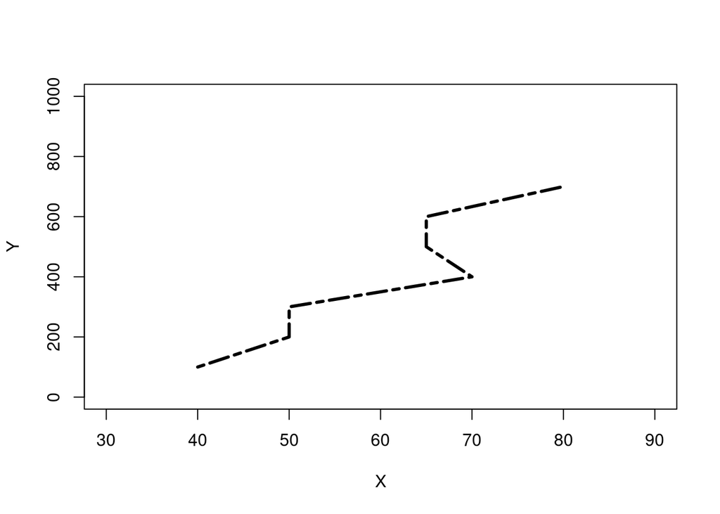

```r
plot(X, Y, type = "l", lwd = 3, lty = 6,
     ylim = c(0, 1000), xlim = c(30, 90))
```

# Digression - sampling from probability distributions

`R` provides pseudo-random sampling from many of the common probability distributions. Below we draw 500 realizations from a standard normal distribution. By plotting a histogram of the data, we can obtain at least suggestive evidence that we have indeed drawn from a standard normal distribution. To further corroborate our hypothesis, we add the density of the standard normal distribution to our plot.

See `?distribution` for an overview.

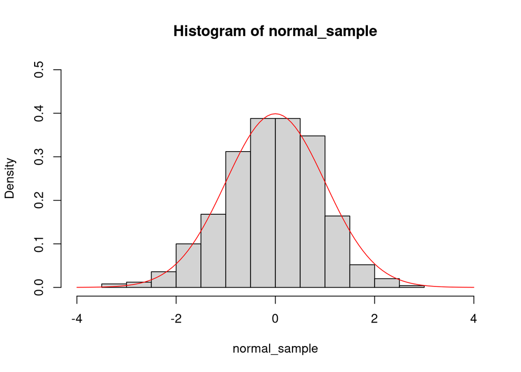

```r
normal_sample <- rnorm(500, mean = 0, sd = 1)
hist(normal_sample, freq = FALSE, xlim = c(-4, 4), ylim = c(0, 0.5))
curve(dnorm(x, mean = 0, sd = 1), col ="red", add = TRUE)
```

# Low-level commands

To modify existing plots, `R` offers a variety of low-level commands. Some of them and their features are listed below.

- `abline(a, b)` adds a straight line with intercept `a` and slope `b`
- `lines(x, y)` joins the points of `x` and `y` and adds the line to the plot
- `points(x, y)` similar to lines, but with points
- `text(x, y, "Text")` adds “Text” at coordinates `(x, y)`
- `legend(x, y, legend,...)` adds a legend at coordinates `(x, y)` using the strings provided in `legend`

[figure not shown]

```r
curve(dnorm(x, mean = 0, sd = 1), from = -7.5, to = 7.5, lty = 1)
curve(dnorm(x, mean = 0, sd = 2), add = TRUE, col = "red", lwd = 2, lty = 2)
lines(seq(-7.5, 7.5, length.out = 1000),
      dnorm(seq(-7.5, 7.5, length.out = 1000), sd = 1.5), col = "blue", lty = 3, lwd = 2)
legend("topleft",
       c(expression(paste(mu == 0," und ", sigma == 2)),
         expression(paste(mu == 0," und ", sigma == 1)),
         expression(paste(mu == 0," und ", sigma == 1.5))),
       lwd = c(1, 2, 2), lty = 1:3, col = c("black", "red", "blue"))
```

To display multiple plots in the same window as a matrix, use

`par(mfrow = c(x1, x2))`

to determine the number of rows (`x1`) and columns (`x2`) of your plot matrix. Use `dev.off()` to reset the setting.

Additionally, you might use RStudio to export your plot to a certain file type.

# Additional Packages

So far we have been using built-in functions that are predefined by `R`, or have been writing functions on our own. In practice many functions that are not shipped with base `R` have already been implemented by someone else and are often available online. In particular we can download so called *packages* which provide a set of functions for a given topic.

For example we could install the `ggplot` package, a package for creating fancy plots; or the `stargazer` package, which helps with creating $\LaTeX$ tables from data frames.

## Installing packages

```r
install.packages("ggplot2")
```

[output not shown]

```r
install.packages("stargazer")
```

[output not shown]

## Load packages

```r
library("ggplot2")
library("stargazer")
```

## ggplot2

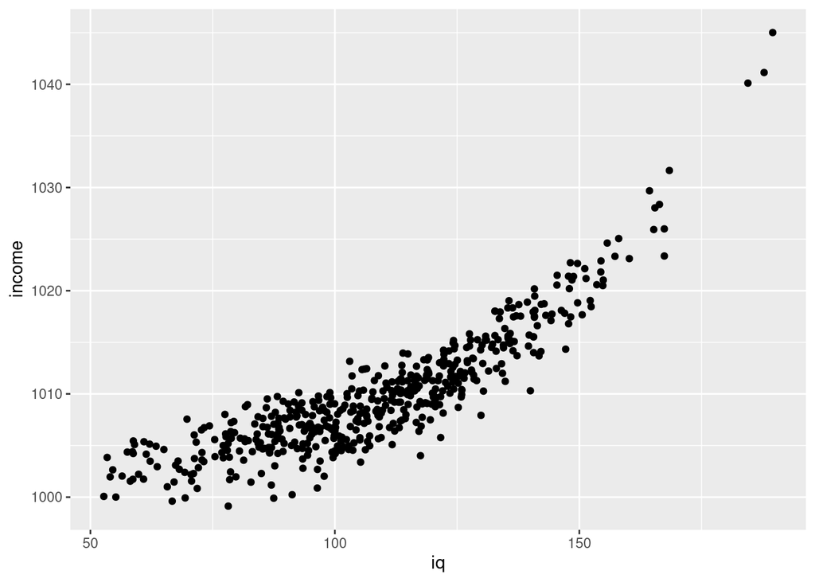

```r
n <- 500
iq <- rnorm(n, mean=110, sd=25)
income <- 1000 + exp(iq / 50) + rnorm(n, sd=2)

df <- data.frame(iq=iq, income=income)

ggplot2::ggplot(df, aes(x=iq, y=income)) +
  geom_point()
```

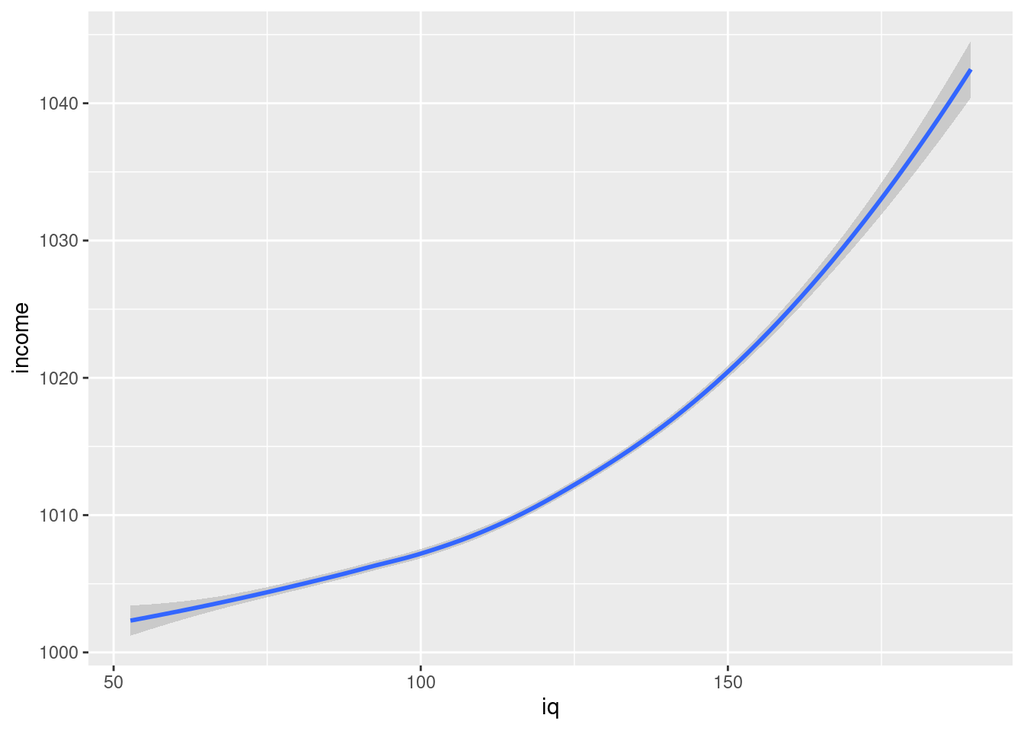

```r
ggplot2::ggplot(df, aes(x=iq, y=income)) +
  geom_smooth()
```

# Statistical Analysis

## Linear Regression (Ordinary Least Squares)

Assume we observe data $\{(y_i, X_i) : i = 1,\dots,n\}$ with outcomes $y_i$ and covariates $X_i$. Assume further that we impose a linear model on the data, i.e. we assume that
$$\begin{align*}
y_i = \beta^\top X_i + \epsilon_i
\end{align*}$$
and we want to estimate $\beta$ using the ordinary least squares method.

**Simulation**:

```r
n <- 100 # number of data points

x1 <- runif(n)
x2 <- rnorm(n)
x3 <- rchisq(n, df=3)
X <- cbind(x1, x2, x3) # covariate matrix

beta <- c(2, 0, -1) # true parameter

eps <- rcauchy(n) # error terms

y <- X %*% beta + eps # simulated outcomes


linear_model <- lm(y ~ X)
summary(linear_model)
```

```
Call:
lm(formula = y ~ X)

Residuals:
   Min     1Q Median     3Q    Max
-7.254 -2.113 -0.719  0.431 50.022

Coefficients:
            Estimate Std. Error t value Pr(>|t|)
(Intercept)  -1.1157     1.6633  -0.671 0.503965
Xx1           4.9849     2.2878   2.179 0.031785 *
Xx2          -0.4946     0.6505  -0.760 0.448907
Xx3          -0.8809     0.2577  -3.419 0.000925 ***
---
Signif. codes:  0 '***' 0.001 '**' 0.01 '*' 0.05 '.' 0.1 ' ' 1

Residual standard error: 6.093 on 96 degrees of freedom
Multiple R-squared:  0.1967,    Adjusted R-squared:  0.1716
F-statistic: 7.835 on 3 and 96 DF,  p-value: 9.88e-05
```

**Using data frames:**

```r
df <- data.frame(income=y, age=x1, edu=x2, nationality=x3)

linear_model <- lm(income ~ age + edu + I(edu**2), data=df)
summary(linear_model)
```

```
Call:
lm(formula = income ~ age + edu + I(edu^2), data = df)

Residuals:
   Min     1Q Median     3Q    Max
-9.421 -2.577 -0.757  1.620 49.067

Coefficients:
            Estimate Std. Error t value Pr(>|t|)
(Intercept)  -4.0979     1.5188  -2.698  0.00824 **
age           6.3453     2.3799   2.666  0.00900 **
edu          -1.0761     0.6617  -1.626  0.10720
I(edu^2)     -0.3759     0.4912  -0.765  0.44608
---
Signif. codes:  0 '***' 0.001 '**' 0.01 '*' 0.05 '.' 0.1 ' ' 1

Residual standard error: 6.434 on 96 degrees of freedom
Multiple R-squared:  0.1044,    Adjusted R-squared:  0.07638
F-statistic: 3.729 on 3 and 96 DF,  p-value: 0.01387
```

**The broom package:**

```r
install.packages("broom")
```

[output not shown]

```r
library("broom")

broom::tidy(linear_model)
```

```
# A tibble: 4 x 5
  term        estimate std.error statistic p.value
  <chr>          <dbl>     <dbl>     <dbl>   <dbl>
1 (Intercept)   -4.10      1.52     -2.70  0.00824
2 age            6.35      2.38      2.67  0.00900
3 edu           -1.08      0.662    -1.63  0.107
4 I(edu^2)      -0.376     0.491    -0.765 0.446
```

**The stargazer package:**

See live coding (or internet).